# Skink counts

## Residuals

Check residuals of the model, it looks OK

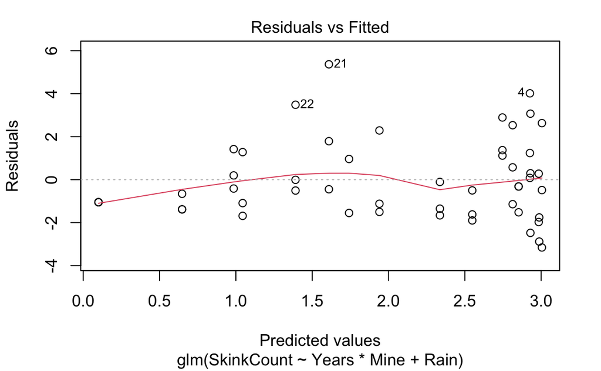

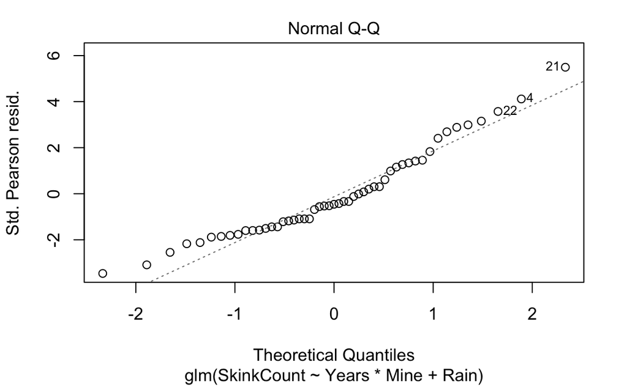

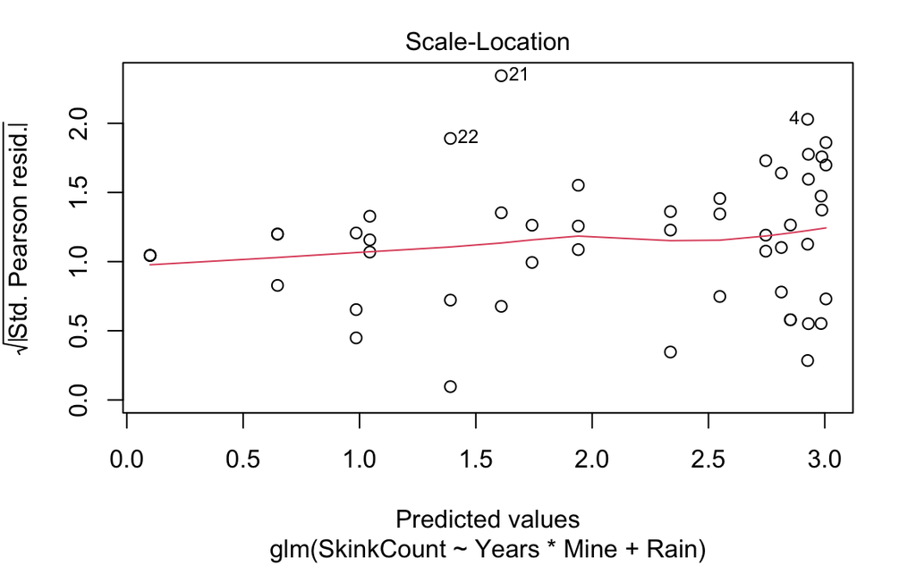

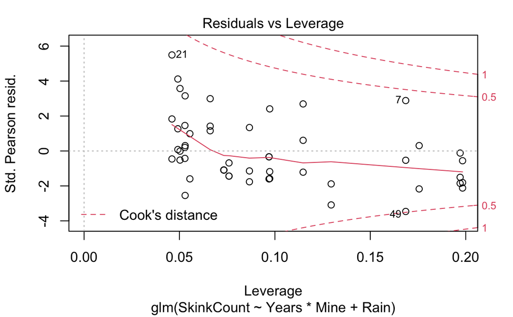

```r
plot(mdl)
```

## Prediction from the model

We calculate model predictions and confidence intervals for the original values of Rain:

```r
pred.data <- skink # %>% mutate(Rain=median(Rainfall_3mth))
prd <- predict(mdl,pred.data,type="link",se.fit=T)
ilink <- mdl$family$linkinv
pred.data$prediction <- ilink(prd$fit)
pred.data$pred_upper <- ilink(prd$fit + 1.96 * prd$se.fit)
pred.data$pred_lower <- ilink(prd$fit - 1.96 * prd$se.fit)
```

But we also want to check the prediction confidence interval for the range of rainfall values:

```r
pred.data %<>%  mutate(Rain=min(Rainfall_3mth))
prd <- predict(mdl,pred.data,type="link",se.fit=T)
pred.data$pred_min_upper <- ilink(prd$fit + 1.96 * prd$se.fit)
pred.data$pred_min_lower <- ilink(prd$fit - 1.96 * prd$se.fit)

pred.data %<>%  mutate(Rain=max(Rainfall_3mth))
prd <- predict(mdl,pred.data,type="link",se.fit=T)
pred.data$pred_max_lower <- ilink(prd$fit - 1.96 * prd$se.fit)
pred.data$pred_max_upper <- ilink(prd$fit + 1.96 * prd$se.fit)
```

## Figure

First create a basic plot:

```r
clrs <- palette()[c(3,7)]
names(clrs) <- c("Unmined reference","Mined")

basic_plot <-
ggplot(skink) + geom_point(aes(y = SkinkCount, x=Time, colour = Mine),size=2) + ggtitle("") +
  xlab("Year") + ylab("Count of Skinks") +
  scale_x_continuous(name="Year", breaks=2015:2022) +
  scale_color_discrete(type = clrs)  + theme_bw() + theme(axis.text.x = element_text(angle = 45, vjust = 1, hjust=1)) + guides(colour='none') + facet_wrap(vars(Mine,Site),ncol=3,nrow=2)
```

This is the plot with the prediction and 95% C.I. with the measured values of rain:

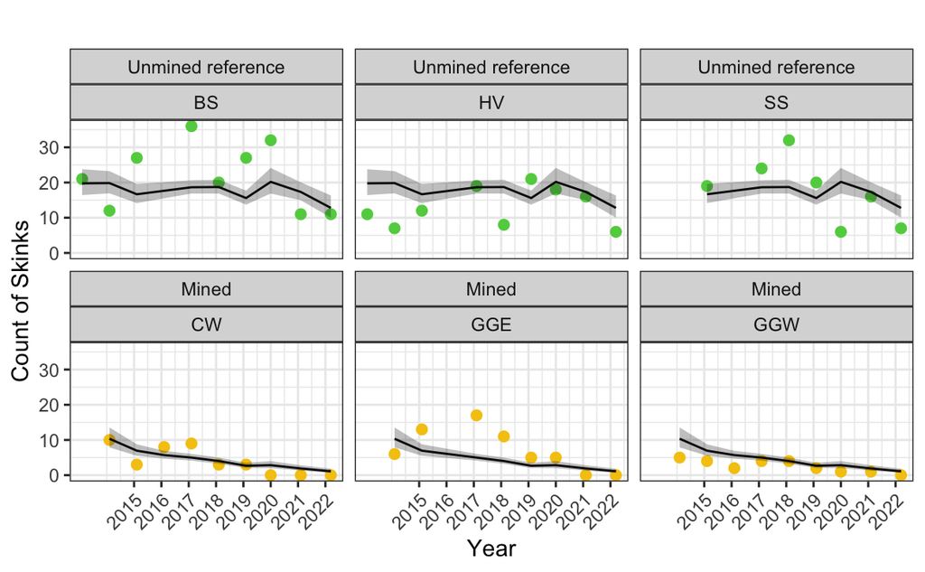

```r
  basic_plot +
  geom_line(data=pred.data,aes(x=Time,y=prediction)) +  geom_ribbon(data=pred.data,aes(x=Time,y=prediction,ymin=pred_lower,ymax=pred_upper),col=NA,lty=0,alpha=0.3)
```

This is the plot with the prediction and 95% C.I. with the range of values of rain:

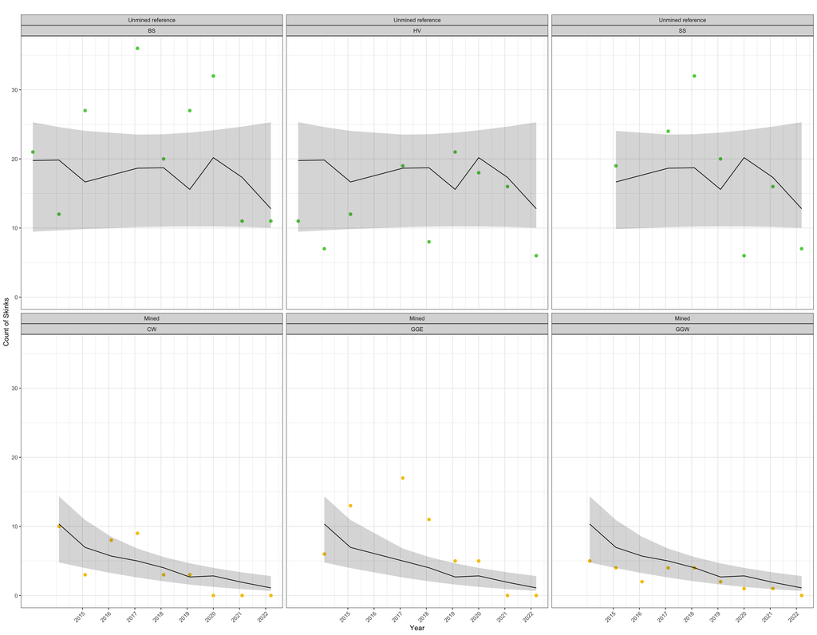

```r
  basic_plot +
  geom_line(data=pred.data,aes(x=Time,y=prediction)) +  geom_ribbon(data=pred.data,aes(x=Time,y=prediction,ymin=pred_max_lower,ymax=pred_min_upper),col=NA,lty=0,alpha=0.2)
```